# Intro to R Markdown

Roy Thomas

2023-08-28

R Markdown documents are documents that combine text, R code, and R output, including figures. They are a great way to produce self-contained and documented statistical analyses.

In this first worksheet, you will learn how to do some basic markdown editing. After you have made a change to the document, press “Knit HTML” in R Studio and see what kind of a result you get.

Edit only below this line.

## 1. Basic Markdown editing

Try out basic R Markdown features, as described here: https://rmarkdown.rstudio.com/authoring_basics.html. - Write text that is in bold. - Write text that is in italics. - write text that is in different sized “headers” - Create a bulleted list - Create a numbered list - Create a nested list

Some caveats: In some versions, there has to be a SPACE between the hash tags and the header text. In some versions, there has to be TWO SPACES at the end of the text (to denote end of line)

## 2. Embedding R code

R code embedded in R chunks will be executed and the output will be shown.

```r
# R code goes here
summary(mtcars)
```

```
##       mpg             cyl             disp             hp
##  Min.   :10.40   Min.   :4.000   Min.   : 71.1   Min.   : 52.0
##  1st Qu.:15.43   1st Qu.:4.000   1st Qu.:120.8   1st Qu.: 96.5
##  Median :19.20   Median :6.000   Median :196.3   Median :123.0
##  Mean   :20.09   Mean   :6.188   Mean   :230.7   Mean   :146.7
##  3rd Qu.:22.80   3rd Qu.:8.000   3rd Qu.:326.0   3rd Qu.:180.0
##  Max.   :33.90   Max.   :8.000   Max.   :472.0   Max.   :335.0
##       drat             wt             qsec             vs
##  Min.   :2.760   Min.   :1.513   Min.   :14.50   Min.   :0.0000
##  1st Qu.:3.080   1st Qu.:2.581   1st Qu.:16.89   1st Qu.:0.0000
##  Median :3.695   Median :3.325   Median :17.71   Median :0.0000
##  Mean   :3.597   Mean   :3.217   Mean   :17.85   Mean   :0.4375
##  3rd Qu.:3.920   3rd Qu.:3.610   3rd Qu.:18.90   3rd Qu.:1.0000
##  Max.   :4.930   Max.   :5.424   Max.   :22.90   Max.   :1.0000
##        am              gear            carb
##  Min.   :0.0000   Min.   :3.000   Min.   :1.000
##  1st Qu.:0.0000   1st Qu.:3.000   1st Qu.:2.000
##  Median :0.0000   Median :4.000   Median :2.000
##  Mean   :0.4062   Mean   :3.688   Mean   :2.812
##  3rd Qu.:1.0000   3rd Qu.:4.000   3rd Qu.:4.000
##  Max.   :1.0000   Max.   :5.000   Max.   :8.000
```

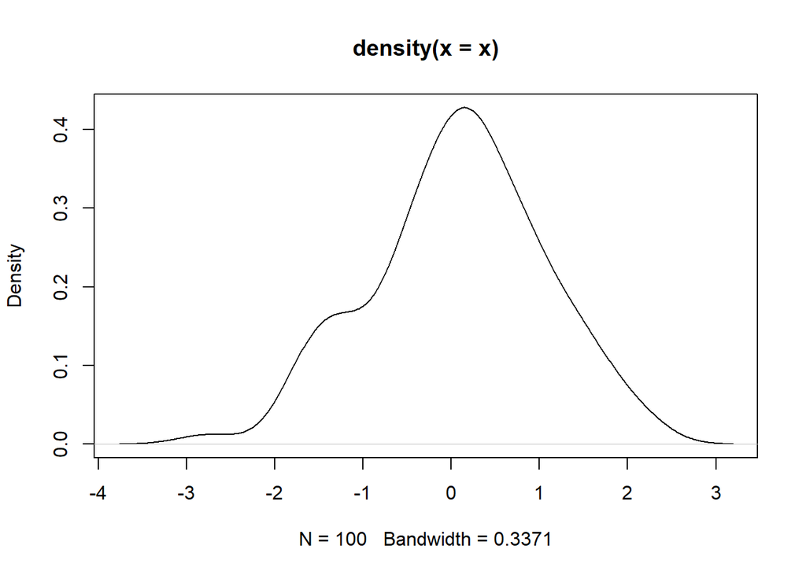

```r
x <- rnorm(100)  # random sample from normal distribution
dens <- density(x)    # calculate density


plot(dens)            # plot density
```

Now you try it. For example, take the built-in data set `cars`, which lists speed and stopping distance for cars from the 1920. Plot speed vs. distance. Then write a few sentences describing what you see.

Here are some hints:  
To figure out what the cars dataset is, use ?cars  
You can LOOK at the dataset with various commands, like “head”, “glimpse”, “summary”… Remember that in each of these commands, you have to provide the name of the dataset as an argument.

To do a simple plot, use the plot(x,y) command, where x and y are the names of the COLUMNS. So, for instance, x would be cars$speed